# Chapter 3 Time Series Decomposition

Dina Dinh

2022-10-06

#Chapter 3: Time Series Deposition

Can think of a time series as comprising three components: a trend-cycle component, a seasonal component, and a remainder component (containing anything else in the time series).

#3.1 Transformation and Adjustments

Four kinds of adjustments: calendar adjustments, population adjustments, inflation adjustments and mathematical transformations. Purpose of adjustments and transformations is to simplify the patterns in the historical data by removing known sources of variation, or by making the pattern more consistent.

Calendar adjustment: - can be variations due to calculating my month/season, so eliminate variation by calculating by day, etc.

Population adjustment: - For most data that are affected by population changes, it is best to use per-capita data rather than the totals.

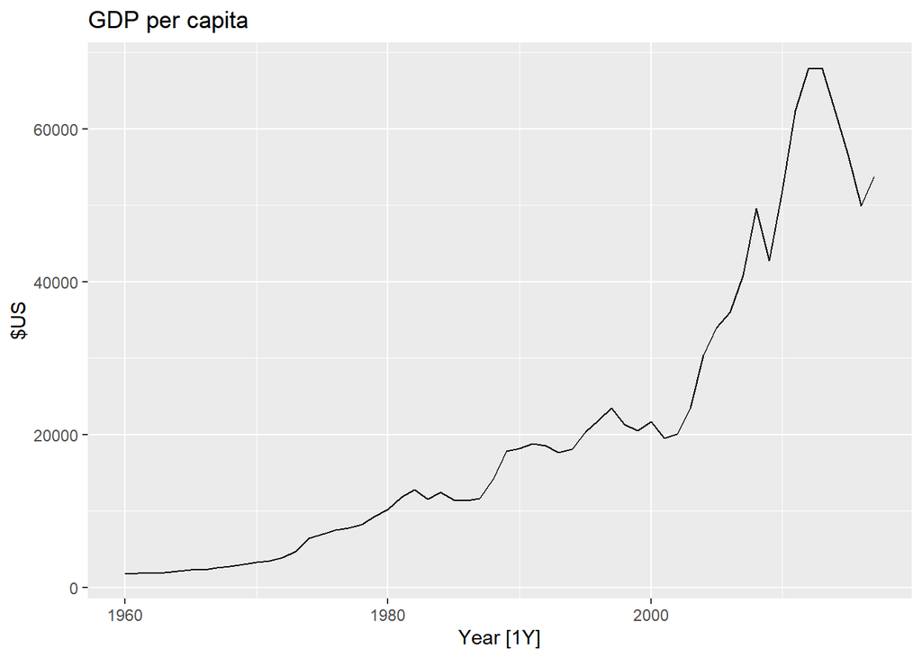

```r
global_economy %>%
  filter(Country == "Australia") %>%
  autoplot(GDP/Population) +
  labs(title= "GDP per capita", y = "$US")
```

# Exercise 7

```
## Plot variable not specified, automatically selected `.vars = Gas`
```

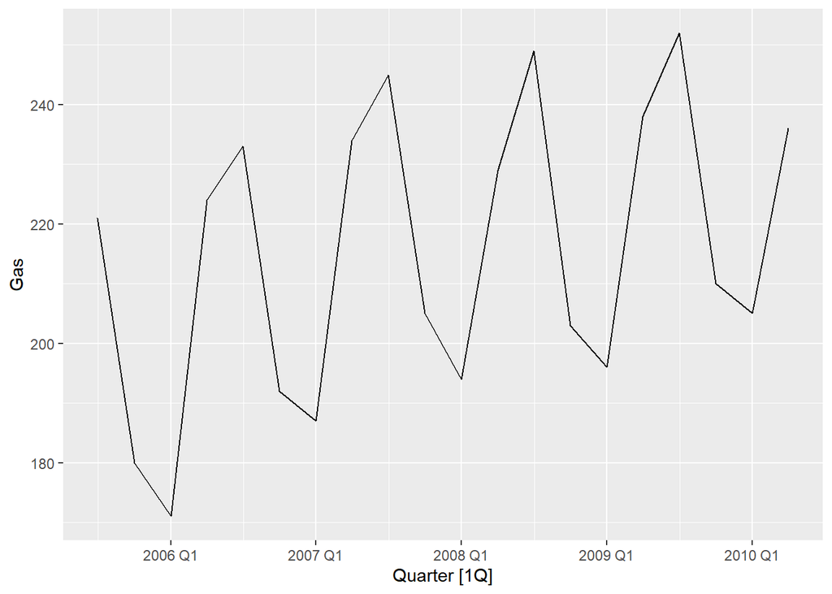

```r
gas <- tail(aus_production, 5*4) %>% select(Gas)
autoplot(gas)
```

```r
classical_decomposition(gas, type = "multiplicative")
```

```
## <Classical decomposition model definition>
```

# 3.1 :

-Are you trying to make these adjustments so you can view the data without the obvious trend? -Why do we do transformations?– do algebra to get it into a format thats easier to understand then once we make our interpretation, we transform back, data doesnt change

# 3.2:

-Did i miss something? What does it mean level of time series? -what does mean by decomposition–break into trends, periodic behavior

–When the variation in the seasonal pattern, or the variation around the trend-cycle, appears to be proportional to the level of the time series, then a multiplicative decomposition is more appropriate.

–An alternative to using a multiplicative decomposition is to first transform the data until the variation in the series appears to be stable over time, then use an additive decomposition.

–STL mean seasonal and trend, similar to additive decomp, but STL is more flexible

–If the variation due to seasonality is not of primary interest, the seasonally adjusted series can be useful.

–Seasonally adjusted series contain the remainder component as well as the trend-cycle.

– remainder gives u an estimate of the maximum error u get when u try to make predictions

# 3.3

–The first step in a classical decomposition is to use a moving average method to estimate the trend-cycle –moving averages takes an average of a group of every few numbers in the data –the bigger the grou of numbers, the smoother the line –It is possible to apply a moving average to a moving average. One reason for doing this is to make an even-order moving average symmetric. –an odd order MA should be followed by an odd order MA. –A major advantage of weighted moving averages is that they yield a smoother estimate of the trend-cycle.

–11-MA is average of previous 5 units, later 5 units, and today –MA does lose some data. –why do it? bc some are too jagged and hard to analyze, and thats how u get trend -can explain the combo of using trend cycle and seasonal data

–weighted MA: the weight of the points away from target point is getting smaller

# 3.4

–if dont know which one to use (additive or multiplicative), try both and use the one with the smallest remainder